# Final Project

Thuy Minh Nhan Do

2025-11-7

## 1. My Data

**Dataset:** FiveThirtyEight “College Majors”  
**Source:** [FiveThirtyEight Data GitHub](https://github.com/fivethirtyeight/data/tree/master/college-majors)

**What’s in it:**

- **all-ages.csv**: Employment & salary for all workers by major.
- **recent-grads.csv**: Outcomes for recent graduates.
- **women-stem.csv**: Gender representation and salaries in STEM majors.

This database contains information about U.S. college graduates, including:

- `Major` – Name of the college major
- `Major_category` – Category grouping like STEM, Arts, Business, or Humanities
- `Total` – Total number of people with that degree
- `Employed` / `Employed_full_time_year_round` – Number of employed graduates
- `Median` – Median salary for graduates
- `Unemployed` / `Unemployment_rate` – Unemployment rate for graduates
- `P25th`, `P75th` - 25th and 75th percentile salaries in a major.
- `Women` / `Men` – Number of graduates by gender.
- `ShareWomen` – Proportion of women in the major.

**Project focus:**

This project focuses on uncovering patterns in salary and employment outcomes across college majors. It explores which majors stand out as particularly high or low paying and examines unemployment trends to see whether some well-paid fields also face poor job security. The analysis also identifies the top ten majors by median salary to highlight the most profitable fields. Finally, it investigates whether larger majors with more graduates tend to experience better employment outcomes, offering insight into the relationship between popularity and job prospects.

## 2. Introduction

College majors significantly influence salary, career stability, and job opportunities after graduation. While many assume that STEM majors earn the most and face the lowest unemployment, real-world data show more complex patterns. This project analyzes salary distributions, unemployment rates, major size, and gender representation across college majors using data from FiveThirtyEight. The goal is to uncover trends and exceptions, providing a detailed picture of employment and income outcomes in the U.S. workforce.

## 3. Research Questions / Planned Graphs

**Questions I plan to ask:**

- Which major categories offer the highest median salaries?
- How does median salary relate to unemployment rate across majors?
- Which majors have the top median salaries overall?
- Does major size correlate with unemployment rate?
- How does salary range (P25–P75) differ across majors?
- How does the share of women in STEM relate to median salary?
- How does unemployment differ between all workers and recent graduates?

## 4. Analysis & Visualizations

**1. Average Median Salary by Major Category**

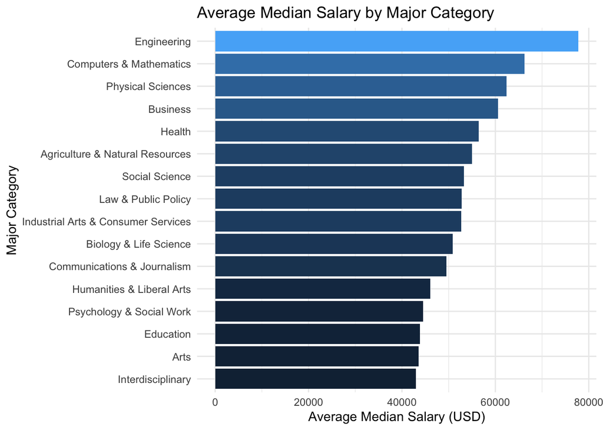

**2. Median Salary vs. Unemployment Rate**

We analyzed the relationship between salary and unemployment by plotting each major on a scatter plot. High-paying majors generally have lower unemployment rates, but there are exceptions. Some Arts and Social Science majors maintain moderate unemployment despite modest earnings, while a few Business and Social Science fields have higher unemployment. This plot also considers total graduates, showing that major size can influence outcomes but is not a guarantee of job security.

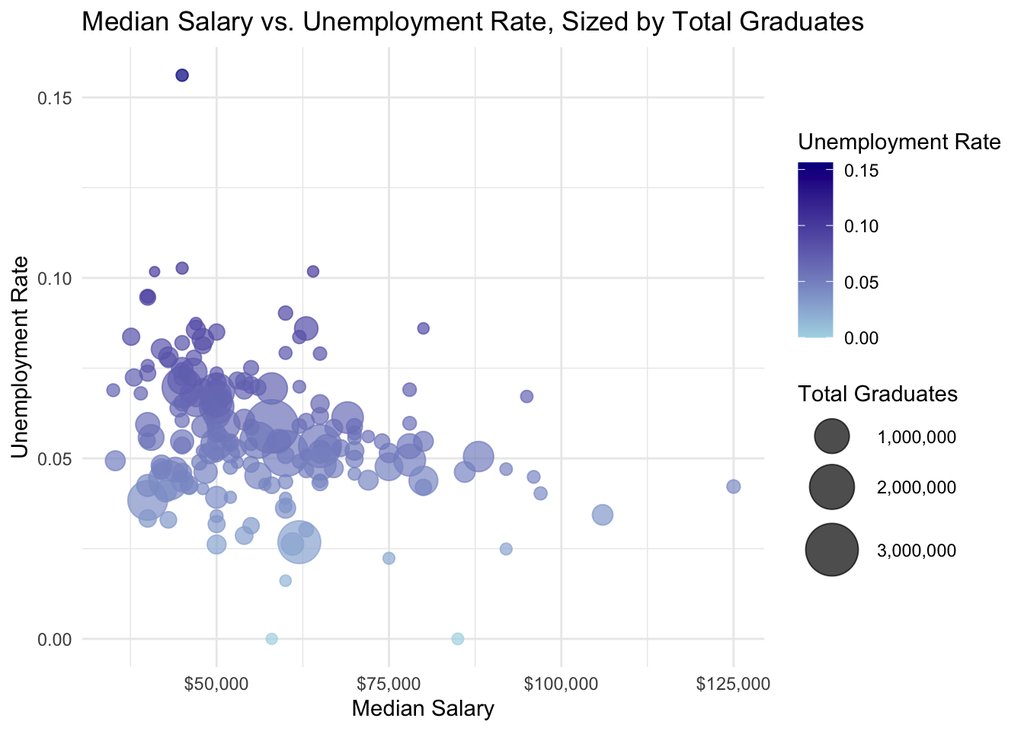

The scatter plot highlights both general trends and notable exceptions. It shows that while higher salaries usually correlate with lower unemployment, some majors defy this pattern. Bubbles representing larger majors cluster around consistent outcomes, while smaller majors vary more widely.

**3. Top 10 Highest-Paying Majors**

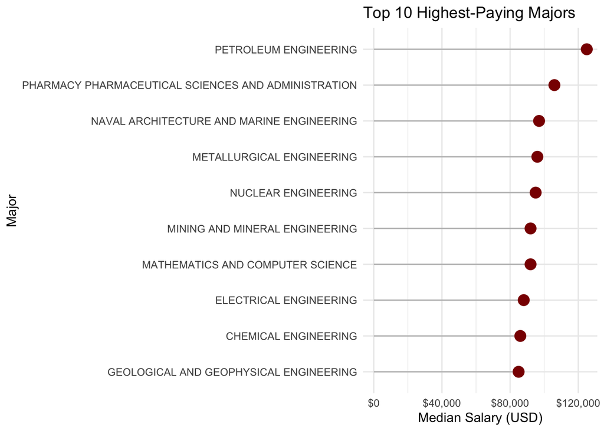

The lollipop chart clearly shows the dominance of technical majors. It also emphasizes differences within the top 10, highlighting how certain engineering majors far exceed others in median salary.

**4. Total Graduates vs. Unemployment Rate**

We explored how major size affects unemployment. Smaller majors show wide variability, with some experiencing high or low unemployment. Larger majors exhibit more consistent outcomes, though size alone does not determine the outcome.

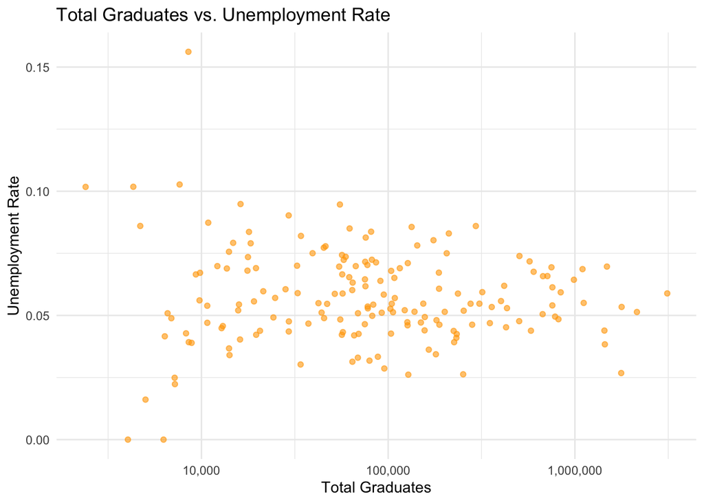

The scatter plot demonstrates these trends. Using a log scale allows us to compare small and large majors clearly, revealing patterns that might not be visible on a linear scale.

**5. Salary Range (P25–P75) for Top Majors**

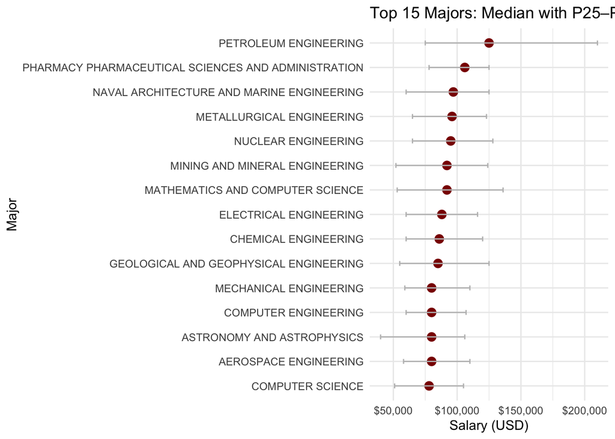

The chart shows that even within high-paying majors, individual earnings can vary significantly, which is useful for understanding potential income outcomes for graduates.

**6. Share of Women vs. Median Salary in STEM**

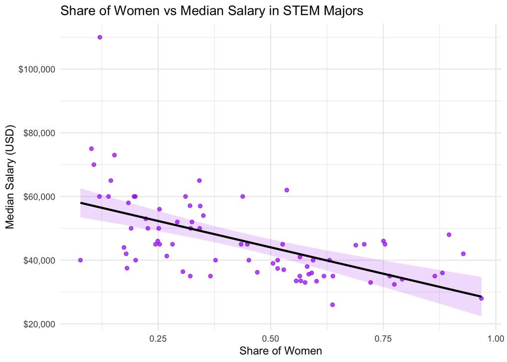

**7. Unemployment: All Workers vs. Recent Graduates**

Finally, we compared unemployment rates for all workers versus recent graduates. Recent graduates generally experience slightly higher unemployment, reflecting entry-level challenges. Some majors remain consistently low or high, suggesting field-specific factors dominate over experience level.

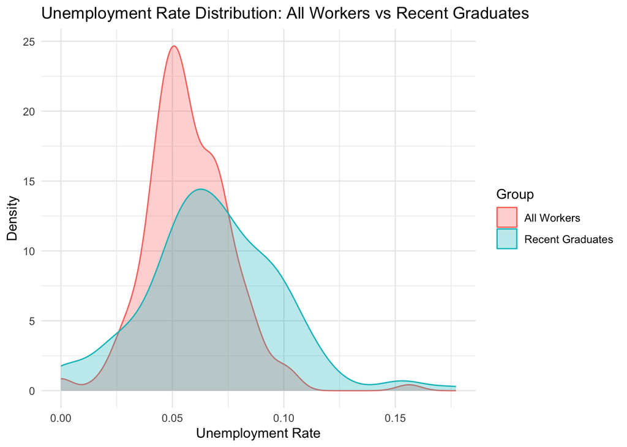

The density plot clearly shows differences between recent graduates and all workers, highlighting that experience and time in the workforce influence employment outcomes.